# Lab 03 - Descriptive Analysis

## Question 1

In 1990 the high-value tracts are located on the outskirts of the city, nearly surrounding the low-value tracts located in the city center and smaller pockets moving outward.

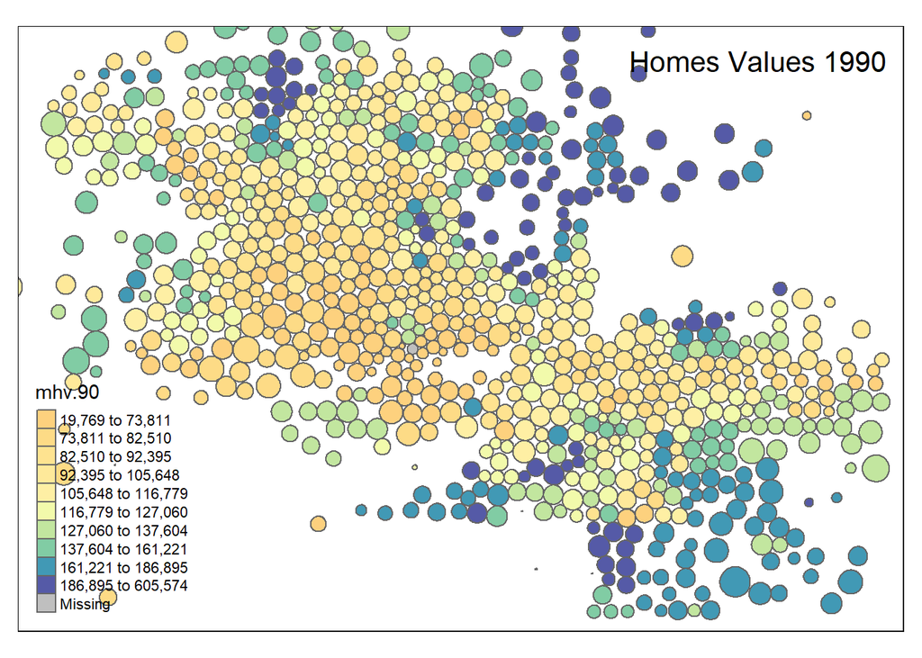

```r
#Homes Values 1990
phx <- spTransform( phx, CRS("+init=epsg:3395") )

bb <- st_bbox( c( xmin = -12519146, xmax = -12421368,
                 ymax = 3965924, ymin = 3899074 ),
               crs = st_crs("+init=epsg:3395"))

tm_shape( phx, bbox=bb ) +
  tm_polygons( col="mhv.90", n=10, style="quantile", palette="Spectral" ) +
  tm_layout( "Homes Values 1990", title.position=c("right","top") )
```

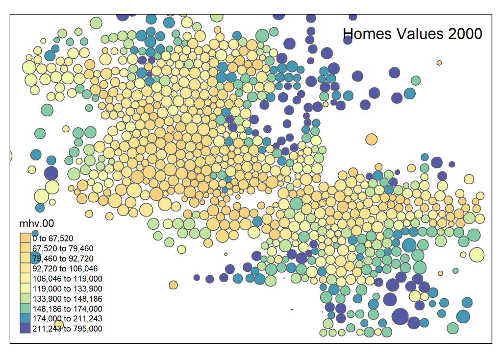

```r
#Homes Values 2000
phx <- spTransform( phx, CRS("+init=epsg:3395") )

bb <- st_bbox( c( xmin = -12519146, xmax = -12421368,
                 ymax = 3965924, ymin = 3899074 ),
               crs = st_crs("+init=epsg:3395"))

tm_shape( phx, bbox=bb ) +
  tm_polygons( col="mhv.00", n=10, style="quantile", palette="Spectral" ) +
  tm_layout( "Homes Values 2000", title.position=c("right","top") )
```

## Question 2

In 2000 the high-value tracts expanded to adjoining tracts. The largest gains were in these high-value adjacent tracts, although there were some tracts towards the city center that saw similar gains.

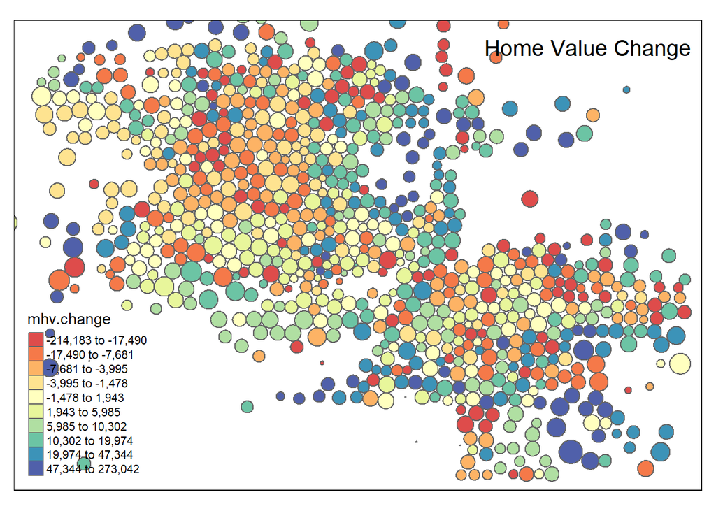

```r
#Home Value Change
tm_shape( phx, bbox=bb ) +
  tm_polygons( col="mhv.change", n=10, style="quantile", palette="Spectral" ) +
  tm_layout( "Home Value Change", title.position=c("right","top") )
```

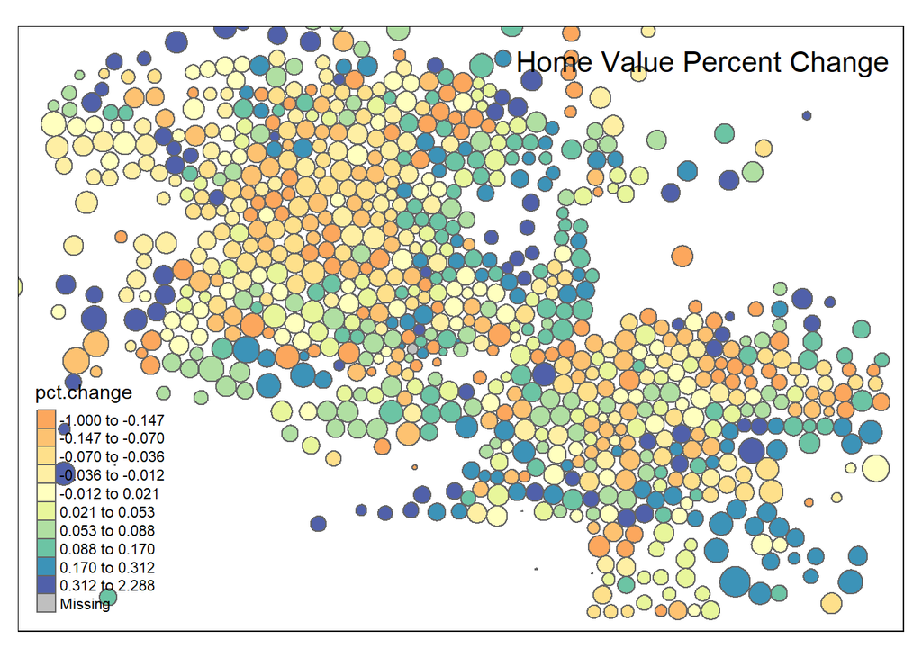

```r
#Home Value Percent Change
tm_shape( phx, bbox=bb ) +
  tm_polygons( col="pct.change", n=10, style="quantile", palette="Spectral" ) +
  tm_layout( "Home Value Percent Change", title.position=c("right","top") )
```

## Question 3

Where gentrification occurs appears to relate to a tract’s proximity to tracts with higher home values. The tracts where gentrification occur tend to be on the outskirts of the city and either adjacent to or surrounded by tracts with a higher initial home value.

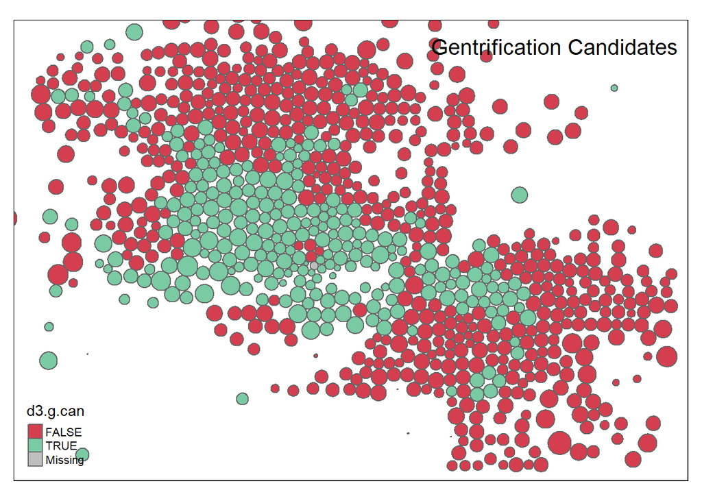

```r
#Gentrification Candidates
tm_shape( phx, bbox=bb ) +
  tm_polygons( col="d3.g.can", n=10, style="cat", palette="Spectral" ) +
  tm_layout( "Gentrification Candidates", title.position=c("right","top") )
```

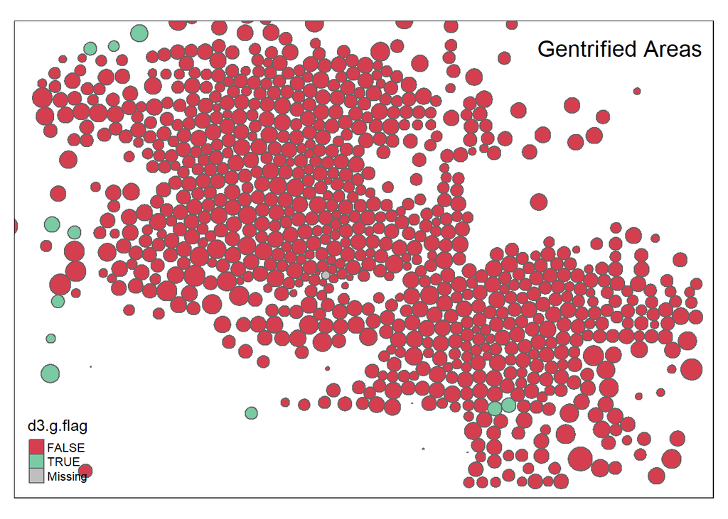

```r
#Gentrified Areas
tm_shape( phx, bbox=bb ) +
  tm_polygons( col="d3.g.flag", n=10, style="cat", palette="Spectral" ) +
  tm_layout( "Gentrified Areas", title.position=c("right","top") )
```